# Residual Contamination Removal in SPLIT

# Introduction

SPLIT purifies spatial transcriptomics profiles by attributing each cell’s expression to its primary cell type, based on a provided deconvolution weight matrix and a reference expression profile. Contamination from neighbouring cell types — whether one or several — is removed proportionally according to their inferred weights.

However, some genes are not specific to any of the cell types assigned to a given cell. These genes represent **residual contamination** from cell types entirely absent from the local deconvolution model, and cannot be resolved through proportional redistribution. They persist in the purified profile regardless of how many components the deconvolution assigns.

This vignette showcases `DO_remove_residual_contamination = TRUE`, a new optional flag available from **SPLIT v0.3.0** in `purify()` that additionally zeros out these non-specific genes using the reference expression profiles. We demonstrate:

1. How to enable residual contamination removal with a single argument.
2. That the additional signal removed is modest — typically 2–5% of total counts on top of what standard SPLIT already removes.
3. That marker gene specificity improves substantially without over-correcting genuine cell-type-specific signal.

> **Note on deconvolution backend** This vignette uses pre-computed RCTD results for convenience. SPLIT is compatible with any deconvolution tool — all that is required is a cells × cell-types weight matrix and a genes × cell-types reference matrix. See `?purify` for details.

> 📝 A significantly faster Python implementation of RCTD (py-RCTD)[https://github.com/p-gueguen/rctd-py] is available for large datasets. SPLIT provides a convenience wrapper `reconstruct_rctd_from_rctdpy()` to load py-RCTD outputs directly into `purify()`. See `?reconstruct_rctd_from_rctdpy` for details.

```r
if (!requireNamespace("SPLIT", quietly = TRUE))
  remotes::install_github("bdsc-tds/SPLIT")
library(SPLIT)
library(spacexr)
library(Seurat)
library(dplyr)
library(ggplot2)
library(patchwork)
library(RColorBrewer)
```

# Load Data

We use the publicly available Xenium breast cancer dataset from:

> **Janesick, A., Shelansky, R., Gottscho, A.D. et al.** *High resolution mapping of the tumor microenvironment using integrated single-cell, spatial and in situ analysis.* *Nature Communications* 14, 8353 (2023). https://doi.org/10.1038/s41467-023-43458-x

```r
if (!requireNamespace("STexampleData", quietly = TRUE))
  remotes::install_github("lmweber/STexampleData")

xe_full_seu <- STexampleData::Janesick_breastCancer_Xenium_rep1()
sp_coords   <- spatialCoords(xe_full_seu)
colnames(sp_coords) <- c("ST_1", "ST_2")

xe <- CreateSeuratObject(
  counts    = counts(xe_full_seu),
  assay     = "Xenium",
  meta.data = as.data.frame(colData(xe_full_seu))
)
xe[["spatial"]] <- CreateDimReducObject(sp_coords, assay = "Xenium", key = "ST_")
xe$x <- sp_coords[, 1]
xe$y <- sp_coords[, 2]
rm(xe_full_seu)
```

```r
# Load pre-computed RCTD results
library(googledrive)
drive_deauth()
file_id    <- "1pTUKq49JbUFwVk7vttjZIFqkx-AKznRF"
local_path <- tempfile(fileext = ".rds")
drive_download(as_id(file_id), path = local_path, overwrite = TRUE)
RCTD <- readRDS(local_path)
RCTD <- SPLIT::run_post_process_RCTD(RCTD)

# Add RCTD results to Xenium object and filter low-count cells
xe <- AddMetaData(xe, RCTD@results$results_df)
xe <- subset(xe, subset = nCount_Xenium >= 10)

# Cell type colour palette
cell_types <- sort(unique(xe$first_type))
pal <- setNames(
  rep(brewer.pal(n = min(12, length(cell_types)), "Set3"),
      length.out = length(cell_types)),
  cell_types
)

cat("Spot class proportions (%):\n")
```

```
## Spot class proportions (%):
```

```r
round(table(xe$spot_class) / ncol(xe) * 100, 1)
```

```
##
##            reject doublet_uncertain   doublet_certain           singlet
##               1.4               1.7              17.5              79.3
```

# Run SPLIT: Standard vs Residual Contamination Removal

We run `purify()` twice — once with default settings, and once with `DO_remove_residual_contamination = TRUE`. Everything else is identical.

```r
raw_counts <- GetAssayData(xe, assay = "Xenium", layer = "counts")

# Standard SPLIT
res_split <- SPLIT::purify(
  counts             = raw_counts,
  rctd               = RCTD,
  DO_purify_singlets = TRUE
)
```

```
## Rescaling deconvolution weights per cell.
```

```
## Processing block 1/4
```

```
## Processing block 2/4
```

```
## Processing block 3/4
```

```
## Processing block 4/4
```

```r
# SPLIT + residual contamination removal
res_split_clean <- SPLIT::purify(
  counts                           = raw_counts,
  rctd                             = RCTD,
  DO_purify_singlets               = TRUE,
  DO_remove_residual_contamination = TRUE,  # <- new flag
  belonging_threshold              = NULL   # auto-derived from reference
)
```

```
##   Auto belonging_threshold: 0.0461 (75th pct of min/max ratio)
```

```
## Cleaning reference profiles ...
```

```
##   Fraction of profile removed per cell type:
```

```
##               B_Cells          CD4+_T_Cells          CD8+_T_Cells                DCIS 1                DCIS 2           Endothelial
##                 0.040                 0.041                 0.041                 0.048                 0.042                 0.040
##        Invasive_Tumor             IRF7+_DCs            LAMP3+_DCs         Macrophages_1         Macrophages_2            Mast_Cells
##                 0.029                 0.055                 0.038                 0.031                 0.035                 0.033
##         Myoepi_ACTA2+         Myoepi_KRT15+     Perivascular-Like Prolif_Invasive_Tumor               Stromal
##                 0.052                 0.054                 0.033                 0.031                 0.041
```

```
## Rescaling deconvolution weights per cell.
```

```
## Processing block 1/4
```

```
## Processing block 2/4
```

```
## Processing block 3/4
```

```
## Processing block 4/4
```

```r
make_purified_seurat <- function(res, raw_counts, xe) {
  obj <- CreateSeuratObject(
    counts    = res$purified_counts,
    meta.data = res$cell_meta,
    assay     = "Xenium"
  )
  obj <- subset(obj, subset = nCount_Xenium > 5)
  shared <- intersect(colnames(obj), colnames(xe))
  obj[["raw"]] <- CreateAssayObject(
    counts = raw_counts[rownames(obj), shared]
  )
  obj <- NormalizeData(obj, assay = "raw",    verbose = FALSE)
  obj <- NormalizeData(obj, assay = "Xenium", verbose = FALSE)
  obj
}

xe_split <- make_purified_seurat(res_split,       raw_counts, xe)
xe_clean <- make_purified_seurat(res_split_clean, raw_counts, xe)
```

# How Much Signal Is Removed?

A key question is whether residual contamination removal over-corrects the data. We quantify count removal at each step.

```r
shared_cells <- Reduce(intersect, list(colnames(xe), colnames(xe_split), colnames(xe_clean)))
cat(sprintf("Shared cells: %s\n", format(length(shared_cells), big.mark = ",")))
```

```
## Shared cells: 161,415
```

```r
total_raw   <- sum(GetAssayData(xe,       assay = "Xenium", layer = "counts")[, shared_cells])
total_split <- sum(GetAssayData(xe_split, assay = "Xenium", layer = "counts")[, shared_cells])
total_clean <- sum(GetAssayData(xe_clean, assay = "Xenium", layer = "counts")[, shared_cells])

cat("\n── Count removal summary ───────────────────────────────────────\n")
```

```
##
## ── Count removal summary ───────────────────────────────────────
```

```r
cat(sprintf("  Raw                                : %s\n",
            format(total_raw, big.mark = ",")))
```

```
##   Raw                                : 31,956,421
```

```r
cat(sprintf("  After SPLIT                        : %s  (%.1f%% removed)\n",
            format(total_split, big.mark = ","),
            100 * (1 - total_split / total_raw)))
```

```
##   After SPLIT                        : 24,785,689  (22.4% removed)
```

```r
cat(sprintf("  After SPLIT + residual removal     : %s  (%.1f%% removed)\n",
            format(total_clean, big.mark = ","),
            100 * (1 - total_clean / total_raw)))
```

```
##   After SPLIT + residual removal     : 23,763,156  (25.6% removed)
```

```r
cat(sprintf("  Additional removal by residual step: %.1f%% of raw counts\n",
            100 * (total_split - total_clean) / total_raw))
```

```
##   Additional removal by residual step: 3.2% of raw counts
```

```r
cat("───────────────────────────────────────────────────────────────\n")
```

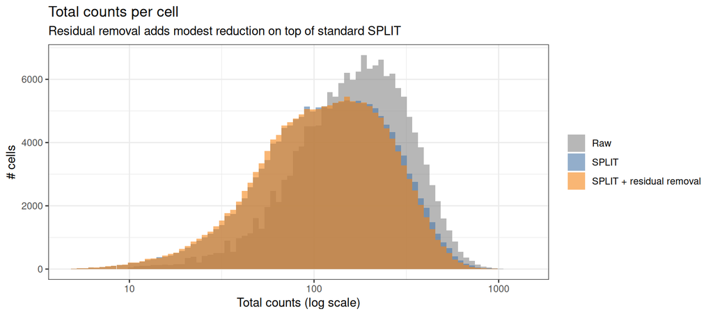

```r
data.frame(
  Raw              = colSums(GetAssayData(xe,       assay = "Xenium", layer = "counts")[, shared_cells]),
  SPLIT            = colSums(GetAssayData(xe_split, assay = "Xenium", layer = "counts")[, shared_cells]),
  SPLIT_clean      = colSums(GetAssayData(xe_clean, assay = "Xenium", layer = "counts")[, shared_cells])
) %>%
  tidyr::pivot_longer(everything(), names_to = "method", values_to = "total_counts") %>%
  mutate(method = factor(method,
                         levels = c("Raw", "SPLIT", "SPLIT_clean"),
                         labels = c("Raw", "SPLIT", "SPLIT + residual removal"))) %>%
  ggplot(aes(x = total_counts, fill = method)) +
  geom_histogram(bins = 80, alpha = 0.6, position = "identity") +
  scale_x_log10() +
  scale_fill_manual(values = c("Raw" = "#888888", "SPLIT" = "#4C78A8",
                               "SPLIT + residual removal" = "#F58518")) +
  theme_bw() +
  labs(title = "Total counts per cell",
       subtitle = "Residual removal adds modest reduction on top of standard SPLIT",
       x = "Total counts (log scale)", y = "# cells", fill = NULL)
```

# Which Genes Improve?

We identify marker genes from the reference and measure how much their non-specific expression decreases after residual contamination removal, while verifying that expression in their target cell type is preserved.

```r
reference <- as.matrix(RCTD@cell_type_info$info[[1]])  # genes x cell-types
gene_max  <- apply(reference, 1, max)

# top 5 most specific genes per cell type
top_markers <- do.call(rbind, lapply(colnames(reference), function(ct) {
  scores <- reference[, ct] / (gene_max + 1e-10)
  top    <- sort(scores, decreasing = TRUE)[1:5]
  data.frame(gene = names(top), cell_type = ct, specificity = as.numeric(top))
}))
top_markers     <- top_markers[top_markers$gene %in% rownames(xe), ]
genes_of_interest <- unique(top_markers$gene)
target_lookup   <- top_markers %>%
  group_by(gene) %>%
  slice_max(specificity, n = 1, with_ties = FALSE) %>%
  ungroup() %>%
  dplyr::select(gene, target_ct = cell_type)
```

```r
get_mean_by_ct <- function(obj, genes, ct_col, assay) {
  genes <- genes[genes %in% rownames(obj)]
  mat   <- GetAssayData(obj, assay = assay, layer = "data")[genes, , drop = FALSE]
  grp   <- obj@meta.data[colnames(mat), ct_col]
  all_cts <- unique(grp)
  do.call(rbind, lapply(genes, function(g) {
    m      <- tapply(as.numeric(mat[g, ]), grp, mean)
    m_full <- setNames(rep(0, length(all_cts)), all_cts)
    m_full[names(m)] <- m
    data.frame(gene = g, cell_type = names(m_full), mean_expr = as.numeric(m_full))
  }))
}

expr_raw   <- get_mean_by_ct(xe_split, genes_of_interest, "first_type", "raw")
expr_split <- get_mean_by_ct(xe_split, genes_of_interest, "first_type", "Xenium")
expr_clean <- get_mean_by_ct(xe_clean, genes_of_interest, "first_type", "Xenium")

expr_cmp <- expr_raw %>%
  dplyr::rename(raw = "mean_expr") %>%
  left_join(expr_split %>% dplyr::rename(split = "mean_expr"), by = c("gene", "cell_type")) %>%
  left_join(expr_clean %>% dplyr::rename(clean = "mean_expr"), by = c("gene", "cell_type")) %>%
  left_join(target_lookup, by = "gene") %>%
  mutate(
    is_target   = cell_type == target_ct,
    improvement = split - clean
  )

improved <- expr_cmp %>%
  group_by(gene) %>%
  summarise(
    mean_improvement_nontarget = mean(improvement[!is_target], na.rm = TRUE),
    mean_improvement_target    = mean(improvement[ is_target], na.rm = TRUE),
    .groups = "drop"
  ) %>%
  filter(mean_improvement_nontarget > 0.02, mean_improvement_target < 0.05) %>%
  arrange(desc(mean_improvement_nontarget))

cat(sprintf("Genes with improved non-specific expression: %d / %d\n",
            nrow(improved), length(genes_of_interest)))
```

```
## Genes with improved non-specific expression: 64 / 85
```

```r
print(improved)
```

```
## # A tibble: 64 × 3
##    gene   mean_improvement_nontarget mean_improvement_target
##    <chr>                       <dbl>                   <dbl>
##  1 LUM                         1.67               -0.0531
##  2 POSTN                       1.24               -0.0504
##  3 ACTA2                       1.16               -0.0000926
##  4 HDC                         0.945              -0.0240
##  5 LYZ                         0.699              -0.0418
##  6 PTGDS                       0.617              -0.0659
##  7 CCDC80                      0.575              -0.0497
##  8 PDK4                        0.562              -0.0452
##  9 CXCL12                      0.555              -0.0456
## 10 TRAC                        0.432              -0.0621
## # ℹ 54 more rows
```

# Visualise Improvement

## DotPlot: Raw vs SPLIT vs SPLIT + Residual Removal

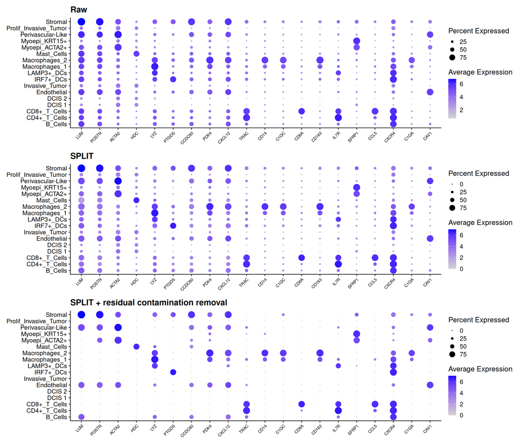

```r
genes_plot <- head(improved$gene, 20)
genes_plot <- genes_plot[genes_plot %in% rownames(xe_split)]

DefaultAssay(xe_split) <- "raw"
p_raw <- DotPlot(xe_split, features = genes_plot,
                 group.by = "first_type", scale = FALSE) +
  ggtitle("Raw") +
  theme(axis.text.x = element_text(angle = 45, hjust = 1, size = 8)) +
  xlab(NULL) + ylab(NULL)

DefaultAssay(xe_split) <- "Xenium"
p_split <- DotPlot(xe_split, features = genes_plot,
                   group.by = "first_type", scale = FALSE) +
  ggtitle("SPLIT") +
  theme(axis.text.x = element_text(angle = 45, hjust = 1, size = 8)) +
  xlab(NULL) + ylab(NULL)

DefaultAssay(xe_clean) <- "Xenium"
p_clean <- DotPlot(xe_clean, features = genes_plot,
                   group.by = "first_type", scale = FALSE) +
  ggtitle("SPLIT + residual contamination removal") +
  theme(axis.text.x = element_text(angle = 45, hjust = 1, size = 8)) +
  xlab(NULL) + ylab(NULL)

p_raw / p_split / p_clean
```

## UMAPs

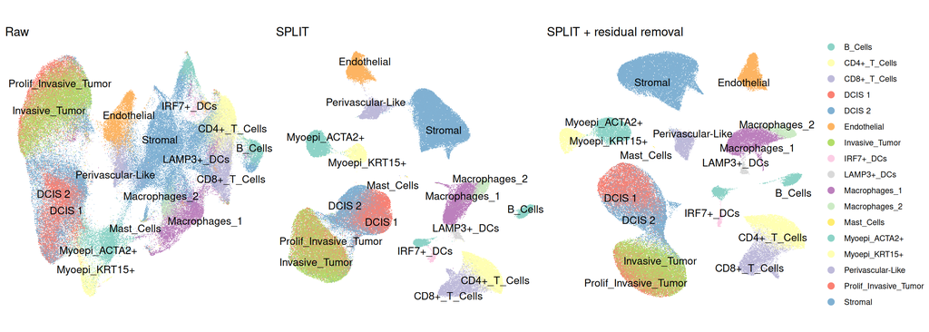

```r
xe_split <- xe_split %>%
  SCTransform(assay = "Xenium", verbose = FALSE) %>%
  RunPCA(verbose = FALSE) %>%
  RunUMAP(dims = 1:20, verbose = FALSE)

xe_clean <- xe_clean %>%
  SCTransform(assay = "Xenium", verbose = FALSE) %>%
  RunPCA(verbose = FALSE) %>%
  RunUMAP(dims = 1:20, verbose = FALSE)

# also need UMAP on raw xe — run SCT if not already done
xe <- xe %>%
  SCTransform(assay = "Xenium", verbose = FALSE) %>%
  RunPCA(verbose = FALSE) %>%
  RunUMAP(dims = 1:20, verbose = FALSE)

p_u1 <- UMAPPlot(xe,       group.by = "first_type", label = T, repel = T, cols = pal) +
  theme_void() + theme(aspect.ratio = 1, legend.position = "none") + ggtitle("Raw")
p_u2 <- UMAPPlot(xe_split, group.by = "first_type", label = T, repel = T, cols = pal) +
  theme_void() + theme(aspect.ratio = 1, legend.position = "none") + ggtitle("SPLIT")
p_u3 <- UMAPPlot(xe_clean, group.by = "first_type", label = T, repel = T, cols = pal) +
  theme_void() + theme(aspect.ratio = 1, legend.position = "right") +
  ggtitle("SPLIT + residual removal")

p_u1 | p_u2 | p_u3
```

## Marker Gene Specificity

Specificity is defined as the mean expression in the target cell type divided by the mean expression across all non-target cell types. Higher values indicate cleaner, more cell-type-specific signal.

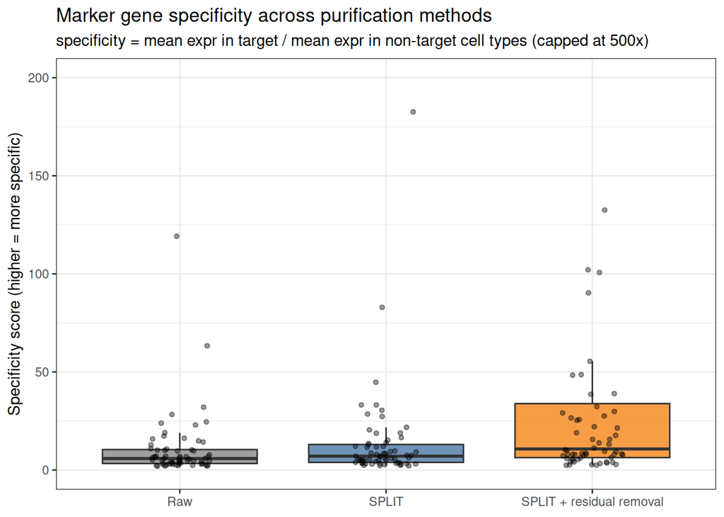

```r
spec_scores <- expr_cmp %>%
  filter(gene %in% improved$gene) %>%
  group_by(gene) %>%
  summarise(
    Raw                      = mean(raw[is_target],   na.rm = TRUE) /
                               (mean(raw[!is_target],  na.rm = TRUE) + 1e-10),
    SPLIT                    = mean(split[is_target], na.rm = TRUE) /
                               (mean(split[!is_target], na.rm = TRUE) + 1e-10),
    `SPLIT + residual removal` = mean(clean[is_target], na.rm = TRUE) /
                               (mean(clean[!is_target], na.rm = TRUE) + 1e-10),
    .groups = "drop"
  ) %>%
  tidyr::pivot_longer(-gene, names_to = "method", values_to = "specificity") %>%
  mutate(
    method      = factor(method, levels = c("Raw", "SPLIT", "SPLIT + residual removal")),
    specificity = pmin(specificity, max(specificity)+10)   # cap extreme values from near-zero denominators
  )

ggplot(spec_scores, aes(x = method, y = specificity, fill = method)) +
  geom_boxplot(outlier.shape = NA, alpha = 0.8) +
  geom_jitter(width = 0.15, size = 1.2, alpha = 0.4) +
  coord_cartesian(ylim = c(0, 200)) +
  scale_fill_manual(values = c("Raw" = "#888888", "SPLIT" = "#4C78A8",
                               "SPLIT + residual removal" = "#F58518")) +
  theme_bw() + theme(legend.position = "none") +
  labs(
    title    = "Marker gene specificity across purification methods",
    subtitle = "specificity = mean expr in target / mean expr in non-target cell types (capped at 500x)",
    x = NULL, y = "Specificity score (higher = more specific)"
  )
```

# Summary

```r
cat("\n── Purification summary ────────────────────────────────────────\n")
```

```
##
## ── Purification summary ────────────────────────────────────────
```

```r
cat(sprintf("  Cells analysed                     : %s\n",
            format(length(shared_cells), big.mark = ",")))
```

```
##   Cells analysed                     : 161,415
```

```r
cat(sprintf("  Raw total counts                   : %s\n",
            format(total_raw, big.mark = ",")))
```

```
##   Raw total counts                   : 31,956,421
```

```r
cat(sprintf("  Removed by SPLIT                   : %s  (%.1f%%)\n",
            format(total_raw - total_split, big.mark = ","),
            100 * (total_raw - total_split) / total_raw))
```

```
##   Removed by SPLIT                   : 7,170,732  (22.4%)
```

```r
cat(sprintf("  Additionally removed by residual step: %s  (%.1f%%)\n",
            format(total_split - total_clean, big.mark = ","),
            100 * (total_split - total_clean) / total_raw))
```

[output not shown]

```r
cat(sprintf("  Genes improved (non-specific expr) : %d / %d marker genes\n",
            nrow(improved), length(genes_of_interest)))
```

```
##   Genes improved (non-specific expr) : 64 / 85 marker genes
```

```r
cat("───────────────────────────────────────────────────────────────\n")
```

Residual contamination removal removes a modest additional fraction of counts (typically 2–5%) on top of standard SPLIT, targeting only genes with no reference support in either the primary or secondary assigned cell type. Marker gene specificity improves substantially without over-correcting genuine cell-type-specific signal.

To enable this feature, simply add one argument to your existing `purify()` call: `DO_remove_residual_contamination = TRUE`